[figure not shown]

# Tecnologías de procesamiento Big Data

Curso 2019-2020

# EJERCICIOS

## Ejercicio 1

1. Crear un nuevo entorno de conda con python 3.7
2. Instalar en este paquete los siguientes paquetes (con las versiones indicadas):

```
PyYAML==5.1
numpy==1.15.4
pandas==0.24.1
python-dateutil==2.7.3
scikit-learn>=0.16.1
scipy>=0.16.0
six==1.12.0
```

1. Exportar el entorno en un fichero **`environment.yml`**. Para ello busca cómo hacerlo en la documentación de conda (https://conda.io/docs/).
2. Borrar por completo el entorno creado (guardando el fichero `environment.yml`).
3. Crear un nuevo entorno basado en el fichero `environment.yml`.
4. Usando pip crear el fichero **`requirements.txt`**
5. ¿Qué diferencias hay entre los dos archivos creados?

## Ejercicio 2

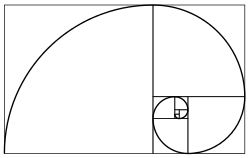

Crear una función `fibonacci` que devuelva el valor de la [Sucesión de Fibonacci](https://es.wikipedia.org/wiki/Sucesi%C3%B3n_de_Fibonacci).

Existe dos maneras de hacer esto:

1. Usando la expresión recursiva
2. Usando la fórmula explicita:

$$ f_n = \frac{\varphi^n - (-\varphi)^{-n}}{\sqrt5},\quad\text{donde }\varphi\;\text{es el número áureo.} $$

Implementar las dos versiones y comparar la [*performance*](https://en.wikipedia.org/wiki/Computer_performance) para n = 1000 usando: `%timeit`

## Ejercicio 3

[figure not shown]

La librería [`BeautifulSoup`](https://www.crummy.com/software/BeautifulSoup/) sirve para parsear páginas web y es muy utilizada. Dado el siguiente código que parsea y extrae el título y puntuación de una película de IMDB.

1. Generar el código necesario para automatizar la descarga y parseo de las siguiente películas.
2. Conseguir una lista de diccionario con el resultado del parseo ordenadas de mayor a menor `ratingvalue`.

```python
peliculas = [

    'http://www.imdb.com/title/tt0071562',
    'http://www.imdb.com/title/tt0110912',
    'http://www.imdb.com/title/tt0050083',
    'http://www.imdb.com/title/tt0108052',
    'http://www.imdb.com/title/tt0468569',
    'http://www.imdb.com/title/tt0068646',
    'http://www.imdb.com/title/tt0167260',
    'http://www.imdb.com/title/tt0060196',
    'http://www.imdb.com/title/tt0137523',
    'http://www.imdb.com/title/tt0111161',

]
```

```python
import requests
from bs4 import BeautifulSoup
```

```python
def parsear_html(texto):
    soup = BeautifulSoup(texto,'lxml')
    item = dict()
    item['titulo'] = soup.find("h1").find(text=True).replace(u'\xa0',' ').strip()
    item['ratingvalue'] = float(soup.select_one('[itemprop="ratingValue"]').text)
    return item
```

**Ejemplo de uso:**

```python
x = 'http://www.imdb.com/title/tt3748528'
```

```python
# Descargamos la url
doc = requests.get(x)
```

```python
doc
```

```
<Response [200]>
```

```python
type(doc.content)
```

```
bytes
```

```python
print(doc.content.strip()[:1000])
```

```
b'<!DOCTYPE html>\n<html\n    xmlns:og="http://ogp.me/ns#"\n    xmlns:fb="http://www.facebook.com/2008/fbml">\n    <head>\n         \n        <meta charset="utf-8">\n        <meta http-equiv="X-UA-Compatible" content="IE=edge">\n\n    <meta name="apple-itunes-app" content="app-id=342792525, app-argu…
```

```python
parsear_html(doc.content)
```

```
{'titulo': 'Rogue One: Una historia de Star Wars', 'ratingvalue': 7.8}
```

## Ejercicio 4

Data la matriz $X$ en el fichero `files/vectores.txt`:

```python
!head files/vectores.txt
```

```
1 0 729.526495207286
1 1 817.180406555498
1 0 1073.54916401173
1 0 529.250604745278
1 0 785.655882930501
1 1 919.5885304745
1 0 825.513330517201
1 1 808.667504297266
1 0 1161.05785403132
1 0 0
```

Se pide:

1. Conseguir un `ndarray` con la información del fichero
2. Dado el vector $\beta$ hacer el producto matriz-vector: $$ p = X \cdot \beta $$

   ```
   beta = np.array([-10.749495878,-0.714877620,0.005738104])
   ```

3. Usar el resultado del producto anterior como entrada de la si guiente función: $$ y = \frac{1}{1+e^{-p}} $$
4. Comprobar que el vector resultante cumple $y\in [0,1]$
5. Quedarse solo con los valores mayores a 0.5 y ordenar el vector

#### TIP:

- Usar la función `np.genfromtxt`

## Ejercicio 5

En la carpeta `files_bolsa` hay un buen número de csv que contienen los datos de la bolsa de Google en algunos días. Por ejemplo:

```python
!head files_bolsa/file_12.csv
```

```
"GOOGL.Open","GOOGL.High","GOOGL.Low","GOOGL.Close","GOOGL.Volume","GOOGL.Adjusted","date"
281.647,284.675,281.281,283.663666,4457100,283.663666,"2009-11-10"
97.287,98.428,95.41,96.046043,37640300,96.046043,"2005-02-01"
242.192,242.863,236.481,237.837845,13194700,237.837845,"2006-10-27"
185.115,186.256,181.992,184.559555,28611700,184.559555,"2006-02-17"
258.093,260.2,254.364,254.779785,6638500,254.779785,"2010-05-11"
800.62,811.44,796.89,808.01001,1959000,808.01001,"2017-01-03"
241.972,241.972,235.531,237.317322,6609700,237.317322,"2008-08-26"
375.631,379.189,375.5,378.223236,3265100,378.223236,"2013-01-31"
360.716,361.862,358.699,360.415405,3833300,360.415405,"2012-12-19"
```

```python
!ls -l files_bolsa | head
```

```
total 432
-rw-rw-r-- 1 jorge jorge 2014 oct 16  2017 file_100.csv
-rw-rw-r-- 1 jorge jorge 2050 oct 16  2017 file_101.csv
-rw-rw-r-- 1 jorge jorge 2051 oct 16  2017 file_102.csv
-rw-rw-r-- 1 jorge jorge 2025 oct 16  2017 file_103.csv
-rw-rw-r-- 1 jorge jorge 2051 oct 16  2017 file_104.csv
-rw-rw-r-- 1 jorge jorge 2043 oct 16  2017 file_105.csv
-rw-rw-r-- 1 jorge jorge 2047 oct 16  2017 file_106.csv
-rw-rw-r-- 1 jorge jorge 2064 oct 16  2017 file_107.csv
-rw-rw-r-- 1 jorge jorge  685 oct 16  2017 file_108.csv
```

Se pide:

1. Automatizar el proceso de lectura de todos los ficheros y conseguir una **lista de `DataFrame` de pandas**.
2. Conseguir un único `DataFrame` con toda la información del punto 1.
3. Ordenar el `DataFrame` por fecha.
4. Calcular el máximo, mínimo y media por mes y año del valor ajustado (`Adjusted`).
5. Pintar la serie temporal del valor de cierre (ver https://pandas.pydata.org/pandas-docs/stable/visualization.html#basic-plotting-plot).

#### TIPS:

- La librería `os` nos puede ayudar para listar los archivos de un directorio.
- En la clase no se ha visto cómo ordenar un `DataFrame`, se puede consultar la [documentación](https://pandas.pydata.org/pandas-docs/stable/).
- Para poder visualizar los gráficos en el notebook hay que poner `%matplotlib inline`)

## Ejercicio 6

En el fichero `files/kpis_marca.json` tenemos los resultados de distintas encuestas e indicadores para varias marcas y años. Como cada medición es de distinta naturaleza y puede cambiar de un año a otro, se quiere pasar todas las mediciones a cuota de mercado (que sumen 1 cada año) de este modo se podrá comparar mejor los resultados.

```python
!head files/kpis_marca.json
```

```
[
  {
    "MARCA": "Marca_3",
    "VARIABLE": "If_I_had_the_opportunity_I_would_purchase_the_products_and_services",
    "X2010": 51.2416,
    "X2011": 57.9881,
    "X2012": 52.832
  },
  {
    "MARCA": "Marca_2",
```

Muchas veces para comparar este tipo de KPI's se calculan las cuotas de mercado. Se pide:

1. Leer el fichero de tipo `json`.
2. Para cada año y variable calcular la cuota de mercado y conseguir un `DataFrame` del estilo:

| VARIABLE | MARCA | X2010 | X2011 | X2012 |
| --- | --- | --- | --- | --- |
| Acts_responsibly_to_protect_the_environment_Clientes | Marca_1 | 0.1836912 | 0.1964758 | 0.2068311 |
| Acts_responsibly_to_protect_the_environment_Clientes | Marca_2 | 0.2077771 | 0.1920705 | 0.1783681 |
| Acts_responsibly_to_protect_the_environment_Clientes | Marca_3 | 0.2034243 | 0.2152717 | 0.1938646 |
| Acts_responsibly_to_protect_the_environment_Clientes | Marca_5 | 0.2008125 | 0.1970631 | 0.2179001 |
| Acts_responsibly_to_protect_the_environment_Clientes | Marca_6 | 0.2042948 | 0.1991189 | 0.2030361 |
| Acts_responsibly_to_protect_the_environment_Publico_General | Marca_1 | 0.2000000 | 0.1931556 | 0.2006932 |
| ... | ... | ... | ... | ... |

#### TIPS:

- Definir como índice la columna `VARIABLE` puede facilitar mucho los cálculos pedidos